# Exploration

```python
import time

import pandas as pd
import numpy as np
import typing
import matplotlib.pyplot as plt

from functools import reduce
from sklearn.decomposition import PCA
from sklearn.model_selection import train_test_split
from sklearn.svm import SVC
from sklearn.cluster import KMeans
from sklearn.ensemble import GradientBoostingClassifier
from sklearn.metrics import classification_report, plot_confusion_matrix, confusion_matrix
from sklearn.model_selection import RandomizedSearchCV
from scipy.stats import uniform, randint


np.random.seed(42)
features = ['bill_length_mm', 'bill_depth_mm', 'flipper_length_mm', 'body_mass_g']
labels = ['sex', 'species']
```

## Create a data-cleaning pipeline

- Data is mean-normalised for use in multiple models

```python
def clean_null_values(df: pd.DataFrame) -> pd.DataFrame:
    """
    Drop all rows that have null values
    """
    print(f'Portion of rows with null values: {round(1-(len(df.dropna())/ len(df)),2)}%')
    return df.dropna()

def collect_subset(df: pd.DataFrame) -> pd.DataFrame:
    """
    Collect a subset of features of interest + labels from data frame
    """
    return df[labels + features]

def normalise(df: pd.DataFrame) -> pd.DataFrame:
    """
    Carry out mean-normalization before creating train-test splits
    """
    df[features] = (df[features] - df[features].mean())/df[features].std()
    return df
```

```python
# Order of data-cleaning transformations indicated by index in list
transformations = [clean_null_values, collect_subset, normalise]

# Transform function applies data transformations successively
transform = lambda x: reduce(lambda d, f : f(d), transformations, x)
```

```python
df = pd.read_csv('data.csv')

# Reproducible transformations
df = transform(df)
```

```
Portion of rows with null values: 0.03%
```

## Data visualisation of body attributes

- Kernel density estimation is used to estimate the probability density function from their respective histograms
- Most of the features appear to have a bi-model distribution, and yet there are 3 species

```python
def create_subplot(ax, feature:str, df: pd.DataFrame):
    df[feature].plot.kde(ax=ax, legend=False)
    df[feature].plot.hist(density=True, ax=ax)
    ax.set_ylabel('Probability')
    ax.set_xlabel(feature)
    ax.grid(axis='y')
    ax.set_facecolor('#d8dcd6')

def plot_densities(df: pd.DataFrame, by_sex=False):
    if by_sex:
        fig, axis = plt.subplots(2, len(features))
        fig.set_figheight(8)
        fig.set_figwidth(24)
        sexes = ['male', 'female']
        for sex in range(2):
            for index in range(len(features)) :
                create_subplot(axis[sex][index], feature=features[index], df= df[df['sex'] == sexes[sex]])

    else:
        fig, axis = plt.subplots(1, len(features))
        fig.set_figheight(4)
        fig.set_figwidth(24)
        for index in range(len(features)) :
            create_subplot(axis[index], feature= features[index], df= df)
```

## Here we can see that most of the attributes are bi-modal without taking 'sex' into account

#### Hypothesis:

Could indicate sexual dimorphism is responsible for the first three features (bill length, bill depth and flipper length)

- However body mass index appears to be 'almost' tri-modal (you can see about 3 bumps)

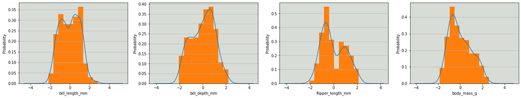

```python
plot_densities(df, by_sex=False)
```

## Updated hypothesis

- There is indeed sexual dimorphism at play
- But when controlling for gender, there are still multi-modalities
- At least two classes seem linearly separable
- Thus, the remaining class must be quite similar to one of the others in terms of its moments or at least defined over a subset of the support
- There may be a **non-linear** combination of features that can further subdivide the similar classes

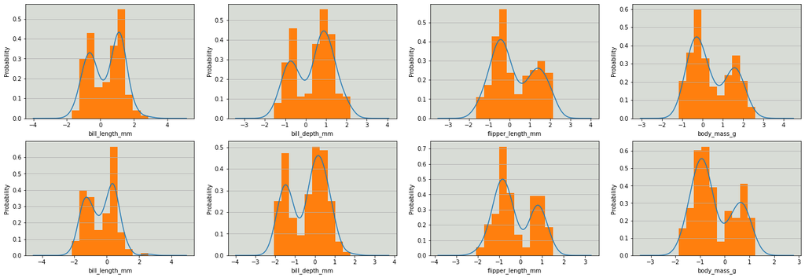

```python
plot_densities(df, by_sex=True)
```

## Begin to prep data for training with different models

```python
def create_train_test_split(df: pd.DataFrame, test_size: float, features: typing.List[str], include_sex= False):
    """
    Create training and test splits to train classifer models, optionally include sex as a feature
    """
    df_slice = df[['species', *features]]
    if include_sex:
        X = df.drop('species', axis=1)
    else:
        X = df.drop(['species', 'sex'], axis=1)
    y = df['species']
    X_train, X_test, y_train, y_test = train_test_split(X,y, test_size=test_size)
    return (X_train, y_train), (X_test, y_test)
```

#### Observations:

- Features 3 & 2 appear to positively co-vary quite strongly (body mass index and flipper length)
- Features 2 & 0 less so (flipper length and bill length)
- Features 2 & 1 appear to negatively co-vary (flipper length and bill_depth)

```python
pca = PCA(n_components = 4)
result = pca.fit(df[features])
pd.DataFrame(result.get_covariance())
```

|  | 0 | 1 | 2 | 3 |
| --- | --- | --- | --- | --- |
| 0 | 1.000000 | -0.228626 | 0.653096 | 0.589451 |
| 1 | -0.228626 | 1.000000 | -0.577792 | -0.472016 |
| 2 | 0.653096 | -0.577792 | 1.000000 | 0.872979 |
| 3 | 0.589451 | -0.472016 | 0.872979 | 1.000000 |

#### Create training and testing splits

```python
training, test = create_train_test_split(df, 0.1, features)
```

#### SVM results confirm non-linearity hypothesis

- Results shown here show here are promising in terms of their information retrieval scores
- After hyperparameter tuning, we seem to find the perfect fit

```python
svc = SVC(kernel='rbf')
svc.fit(training[0], training[1])
y_pred = svc.predict(test[0])
print(classification_report(test[1], y_pred))
```

```
              precision    recall  f1-score   support

      Adelie       0.94      1.00      0.97        15
   Chinstrap       1.00      0.90      0.95        10
      Gentoo       1.00      1.00      1.00         9

    accuracy                           0.97        34
   macro avg       0.98      0.97      0.97        34
weighted avg       0.97      0.97      0.97        34
```

##### Tune hyper-parms

```python
svc = SVC(kernel='rbf')
distributions = dict(kernel=['linear', 'rbf'], C=uniform(0.1, 1000), gamma=uniform(0.1,5))
clf = RandomizedSearchCV(svc, distributions, random_state=0)

start = time.time()
clf.fit(training[0], training[1])
end = time.time()

print(f'Elapsed time in seconds: {round(end - start, 5)}s\n')

y_pred = clf.predict(test[0])

print(classification_report(test[1], y_pred))
```

```
Elapsed time in seconds: 0.21743s

              precision    recall  f1-score   support

      Adelie       1.00      1.00      1.00        15
   Chinstrap       1.00      1.00      1.00        10
      Gentoo       1.00      1.00      1.00         9

    accuracy                           1.00        34
   macro avg       1.00      1.00      1.00        34
weighted avg       1.00      1.00      1.00        34
```

```
<sklearn.metrics._plot.confusion_matrix.ConfusionMatrixDisplay at 0x7f8923d74dc0>
```

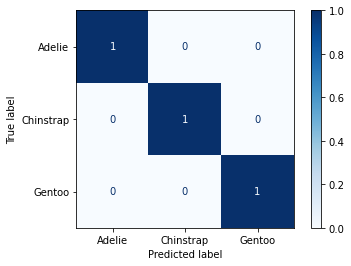

```python
plot_confusion_matrix(clf, test[0], test[1],display_labels=np.sort(df['species'].unique()),cmap=plt.cm.Blues,normalize='true')
```

#### Test a k-means classifier as a sanity-check

- Maybe the SVM is too much for this task
- Poorer results in k-means indicate difficulty distinguishing between classes purely by cluster distance
- This makes sense due to similarity of the distributions
- We can see the Adelie and Chinstrap clusters appear to be more difficult to distinguish
- Further validates the presence of non-linear relationships between features

```python
encodings = {k : v for v,k in enumerate(['Gentoo', 'Adelie', 'Chinstrap' ])}

kmeans = KMeans(n_clusters=3, random_state=0)
kmeans.fit(training[0])

y_pred = kmeans.predict(test[0])

print(classification_report(list(test[1].map(lambda x : encodings[x])), y_pred))
```

```
              precision    recall  f1-score   support

           0       1.00      1.00      1.00         9
           1       0.92      0.80      0.86        15
           2       0.75      0.90      0.82        10

    accuracy                           0.88        34
   macro avg       0.89      0.90      0.89        34
weighted avg       0.89      0.88      0.88        34
```

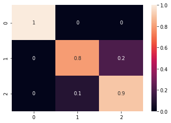

```python
import seaborn as sns
cm = confusion_matrix(list(test[1].map(lambda x : encodings[x])), y_pred, normalize='true')
f = sns.heatmap(cm, annot=True)
```

#### Gradient boosting is as another good candidate for classification

- Dataset is relatively small
- Ensemble methods may be more effective
- Appears to be extremely effective, achieving scores of 1.0 with some default parameters

```python
gBoost = GradientBoostingClassifier(n_estimators=100, learning_rate=1.0,max_depth=1, random_state=0)
gBoost.fit(training[0], training[1])

y_pred = gBoost.predict(test[0])

print(classification_report(test[1], y_pred))
```

```
              precision    recall  f1-score   support

      Adelie       1.00      1.00      1.00        15
   Chinstrap       1.00      1.00      1.00        10
      Gentoo       1.00      1.00      1.00         9

    accuracy                           1.00        34
   macro avg       1.00      1.00      1.00        34
weighted avg       1.00      1.00      1.00        34
```

#### Hyperparameter optimization significantly increases training time as compared with the SVM

```python
gBoost = GradientBoostingClassifier()
distributions = dict(n_estimators=randint(20, 300), learning_rate = uniform(0.1, 10), max_depth=randint(1, 3) )
clf = RandomizedSearchCV(gBoost, distributions, random_state=0)

start = time.time()
clf.fit(training[0], training[1])
end = time.time()

print(f'Elapsed time in seconds: {round(end - start, 5)}s\n')

y_pred = clf.predict(test[0])

print(classification_report(test[1], y_pred))
```

```
Elapsed time in seconds: 10.27043s

              precision    recall  f1-score   support

      Adelie       1.00      1.00      1.00        15
   Chinstrap       1.00      1.00      1.00        10
      Gentoo       1.00      1.00      1.00         9

    accuracy                           1.00        34
   macro avg       1.00      1.00      1.00        34
weighted avg       1.00      1.00      1.00        34
```

```
<sklearn.metrics._plot.confusion_matrix.ConfusionMatrixDisplay at 0x7f8923d12b80>
```

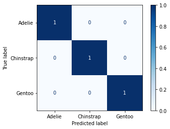

```python
plot_confusion_matrix(clf, test[0], test[1],display_labels=np.sort(df['species'].unique()),cmap=plt.cm.Blues,normalize='true')
```